# Pocillopora Juvenile Fusion

Ariana Huffmyer (R Markdown author)

2019

## Setup

Set up workspace, set options, and load required packages.

```r
rm(list=ls(all=TRUE))
```

```r
library(gridExtra)
library(multcomp)
library(emmeans)
```

```r
library(ggplot2)
library(dplyr)
library(effects)
library(plyr)
library(lattice)
library(glmmTMB)
library(effects)
library(lsmeans)
library(MuMIn)
library(MASS)
library(car)
library(FSA)
library(lmerTest)
library(lme4)
library(blmeco)
library(ggsci)
library(coxme)
library(survival)
library(cowplot)
library(RColorBrewer)
library(tidyverse)
library(partitionBEFsp)
library(factoextra)
library(ggfortify)
library(cowplot)
library(survminer)
```

## 1. GROW OUT SURVIVORSHIP

### **Load data**

Survivorship is measured as binary on each individual spat in the experiment.

```r
#load data
rearing<-read.csv("Data/GrowOut_Responses_PostGenotyping.csv", header=TRUE, sep=",", na.strings="NA")
rearing$Quadrant<-as.factor(rearing$Quadrant)
rearing$Diversity.Type<-relevel(rearing$Diversity.Type, ref="Individual")
rearing$Community<-relevel(rearing$Community, ref="Individual")

#rearing$Total.Juveniles<-as.factor(rearing$Total.Juveniles)
#rearing$Fusion.Partners<-as.factor(rearing$Fusion.Partners)
#rearing$Richness<-as.factor(rearing$Richness)
```

Subset the final timepoint for additional analyses.

```r
final<-rearing[which(rearing$Timepoint == "Final"),]
group<-rearing[which(rearing$Community == "Group"),]
group_final<-group[which(group$Timepoint == "Final"),]
```

### **Analysis**

Analyze with a logistic binomial regression model.

Analyze at the final timepoint.

```r
#with final dataset
survmod2<-glmer(Survivorship ~ Richness + Community + Fusion.Partners + Richness:Fusion.Partners + (1|Parent.Site/Colony) + (1|Tank) + (1|Slide), data=final, family=binomial)
summary(survmod2)
```

```
## Generalized linear mixed model fit by maximum likelihood (Laplace
##   Approximation) [glmerMod]
##  Family: binomial  ( logit )
## Formula:
## Survivorship ~ Richness + Community + Fusion.Partners + Richness:Fusion.Partners +
##     (1 | Parent.Site/Colony) + (1 | Tank) + (1 | Slide)
##    Data: final
##
##      AIC      BIC   logLik deviance df.resid
##    224.6    255.2   -103.3    206.6      212
##
## Scaled residuals:
##      Min       1Q   Median       3Q      Max
## -10.6985  -0.6214   0.3067   0.5208   1.4376
##
## Random effects:
##  Groups             Name        Variance  Std.Dev.
##  Slide              (Intercept) 3.391e-01 0.582352
##  Colony:Parent.Site (Intercept) 4.784e-03 0.069167
##  Parent.Site        (Intercept) 3.560e-06 0.001887
##  Tank               (Intercept) 1.537e-01 0.392056
## Number of obs: 221, groups:
## Slide, 115; Colony:Parent.Site, 21; Parent.Site, 6; Tank, 5
##
## Fixed effects:
##                          Estimate Std. Error z value Pr(>|z|)
## (Intercept)                1.3942     0.5005   2.786  0.00534 **
## Richness                   0.0457     0.2590   0.176  0.85997
## CommunityGroup            -1.9190     0.6414  -2.992  0.00277 **
## Fusion.Partners            3.3668     1.0910   3.086  0.00203 **
## Richness:Fusion.Partners  -0.5213     0.3525  -1.479  0.13924
## ---
## Signif. codes:  0 '***' 0.001 '**' 0.01 '*' 0.05 '.' 0.1 ' ' 1
##
## Correlation of Fixed Effects:
##             (Intr) Rchnss CmmntG Fsn.Pr
## Richness    -0.477
## CommuntyGrp -0.207 -0.608
## Fusn.Prtnrs -0.114  0.411 -0.482
## Rchnss:Fs.P  0.153 -0.458  0.393 -0.929
## convergence code: 0
## Model failed to converge with max|grad| = 0.0112085 (tol = 0.001, component 1)
```

```r
Anova(survmod2)
```

```
## Analysis of Deviance Table (Type II Wald chisquare tests)
##
## Response: Survivorship
##                            Chisq Df Pr(>Chisq)
## Richness                  0.3173  1   0.573223
## Community                 8.9516  1   0.002772 **
## Fusion.Partners          21.3756  1  3.775e-06 ***
## Richness:Fusion.Partners  2.1863  1   0.139245
## ---
## Signif. codes:  0 '***' 0.001 '**' 0.01 '*' 0.05 '.' 0.1 ' ' 1
```

```r
#final dataset
summary(effect(c("Richness", "Fusion.Partners"), xlevels=4, survmod2))
```

```
## NOTE: RichnessFusion.Partners is not a high-order term in the model
```

```
##
##  Richness*Fusion.Partners effect
##         Fusion.Partners
## Richness         0         1         2         3
##        1 0.5061314 0.9463480 0.9967168 0.9998087
##        2 0.5175489 0.9164084 0.9911532 0.9991274
##        3 0.5289481 0.8720208 0.9763849 0.9960299
##        4 0.5403171 0.8089765 0.9384931 0.9821349
##
##  Lower 95 Percent Confidence Limits
##         Fusion.Partners
## Richness         0         1         2         3
##        1 0.3130708 0.8186676 0.9501058 0.9867223
##        2 0.3661859 0.8084490 0.9462577 0.9856340
##        3 0.3374863 0.7366122 0.9027604 0.9645174
##        4 0.2661940 0.5541801 0.6689295 0.7279225
##
##  Upper 95 Percent Confidence Limits
##         Fusion.Partners
## Richness         0         1         2         3
##        1 0.6973806 0.9856964 0.9997934 0.9999973
##        2 0.6657585 0.9660745 0.9985992 0.9999477
##        3 0.7122548 0.9431848 0.9945985 0.9995683
##        4 0.7920387 0.9351828 0.9913962 0.9991155
```

```r
summary(effect("Fusion.Partners", xlevels=4, survmod2))
```

```
## NOTE: Fusion.Partners is not a high-order term in the model
```

```
##
##  Fusion.Partners effect
## Fusion.Partners
##         0         1         2         3
## 0.5169809 0.9182039 0.9915778 0.9991908
##
##  Lower 95 Percent Confidence Limits
## Fusion.Partners
##         0         1         2         3
## 0.3653903 0.8098959 0.9468856 0.9858654
##
##  Upper 95 Percent Confidence Limits
## Fusion.Partners
##         0         1         2         3
## 0.6655093 0.9672972 0.9987155 0.9999543
```

```r
summary(effect("Community", xlevels=4, survmod2))
```

```
##
##  Community effect
## Community
## Individual      Group
##  0.9532330  0.7494544
##
##  Lower 95 Percent Confidence Limits
## Community
## Individual      Group
##  0.8445862  0.5984934
##
##  Upper 95 Percent Confidence Limits
## Community
## Individual      Group
##  0.9870881  0.8571990
```

```r
dispersion_glmer(survmod2) #no overdispersion
```

```
## [1] 0.9350126
```

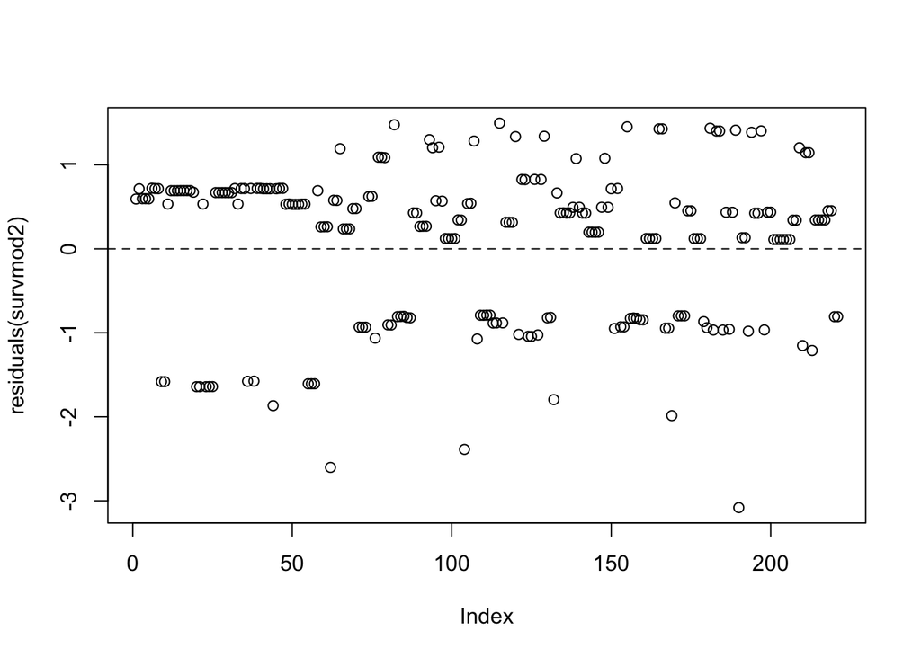

```
## integer(0)
```

```r
plot(residuals(survmod2)) + abline(h=0, lty=2) #Dispersed randomly
```

Create plot for effect of community type.

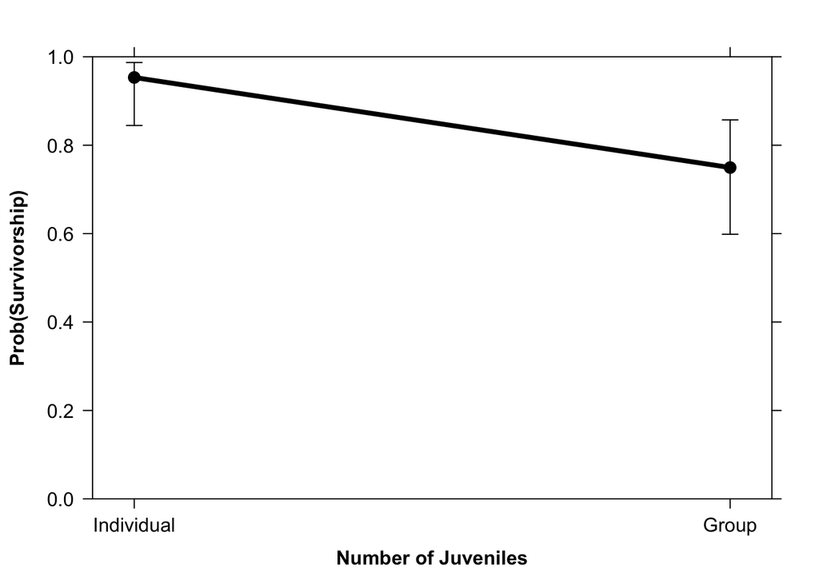

```r
eff.surv1 <- predictorEffect("Community", survmod2)
surv.effects1<-plot(eff.surv1,
                   lines=list(multiline=TRUE,
                              col=c("black"),
                              lty=1),
                   confint=list(style="bars", width=4, col="black"),
                   lwd=4,
                   axes=list(y=list(lim=c(0, 1))),
                   type="response",
                   ylab=expression(bold("Prob(Survivorship)")),
                   legend.position="right",
                   xlab=expression(bold("Number of Juveniles")),
                   main=""); surv.effects1
```

```r
                   #lattice=list(key.args=list(space="right",
                                              #border=FALSE,
                                              #title=expression(bold("Genotypic \nRichness")),
                                              #cex=1,
                                              #cex.title=1)));surv.effects1
```

Create plots for fusion partner effects.

```r
survmod2a<-glmer(Survivorship ~ Richness + Fusion.Partners + Richness:Fusion.Partners + (1|Parent.Site/Colony) + (1|Tank) + (1|Slide), data=final, family=binomial, subset=c(Community=="Group"))
```

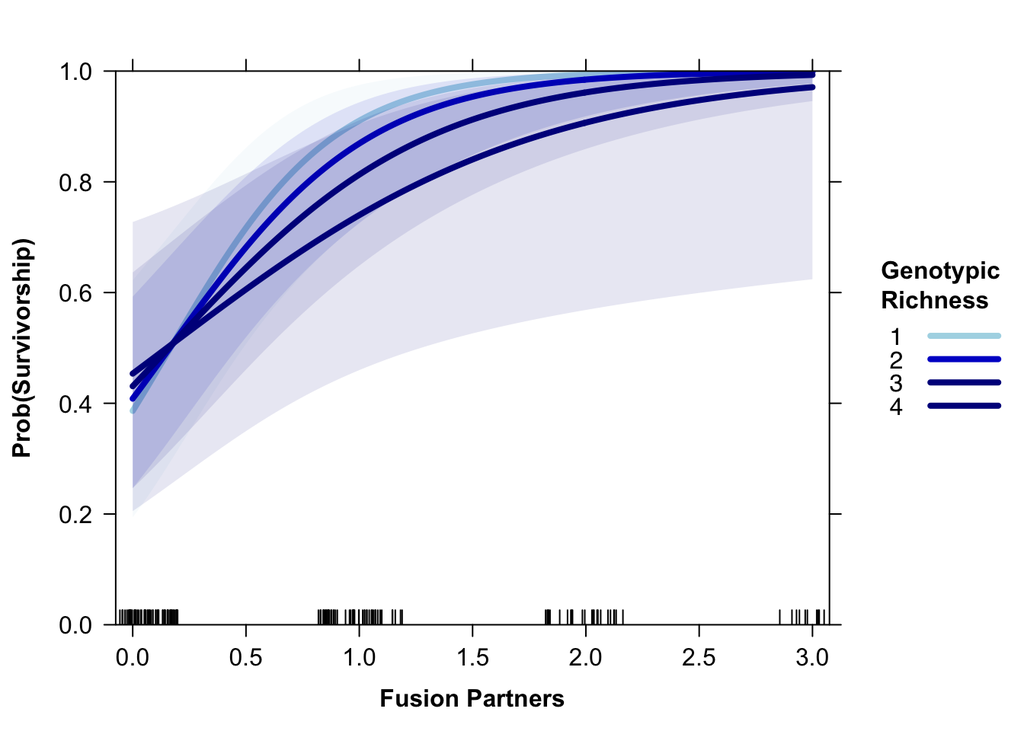

```r
eff.surv2 <- predictorEffect("Fusion.Partners", survmod2a, xlevels=4, rug=TRUE)
surv.effects2<-plot(eff.surv2,
                   lines=list(multiline=TRUE,
                              col=c("lightblue","mediumblue", "blue4", "darkblue"),
                              lty=1),
                   confint=list(style="bands", alpha=0.1),
                   lwd=4,
                   axes=list(y=list(lim=c(0, 1))),
                   type="response",
                   ylab=expression(bold("Prob(Survivorship)")),
                   legend.position="right",
                   xlab=expression(bold("Fusion Partners")),
                   main="",
                   lattice=list(key.args=list(space="right",
                                              border=FALSE,
                                              title=expression(bold("Genotypic \nRichness")),
                                              cex=1,
                                              cex.title=1)));surv.effects2
```

```r
survmod2b<-glmer(Survivorship ~ Fusion.Partners + (1|Parent.Site/Colony) + (1|Tank) + (1|Slide), data=final, family=binomial, subset=c(Community=="Group"))
```

```
## boundary (singular) fit: see ?isSingular
```

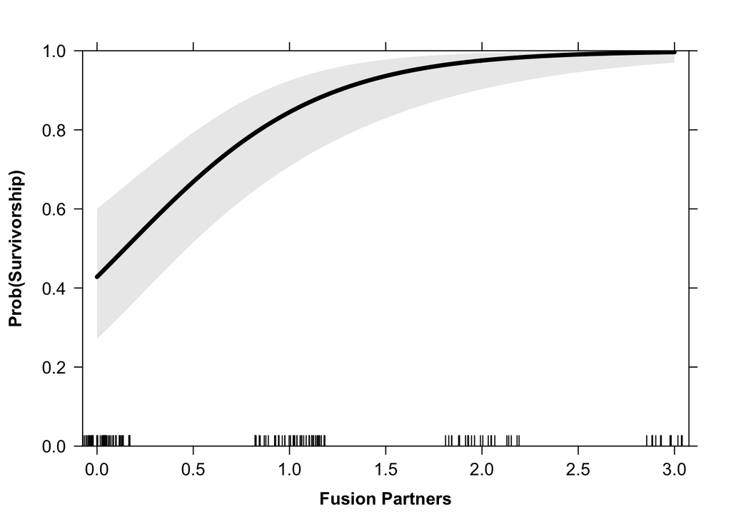

```r
eff.surv2b <- predictorEffect("Fusion.Partners", survmod2b, xlevels=4, rug=TRUE)
surv.effects2b<-plot(eff.surv2b,
                   lines=list(multiline=TRUE,
                              col=c("black"),
                              lty=1),
                   confint=list(style="bands", alpha=0.1),
                   lwd=4,
                   axes=list(y=list(lim=c(0, 1))),
                   type="response",
                   ylab=expression(bold("Prob(Survivorship)")),
                   legend.position="right",
                   xlab=expression(bold("Fusion Partners")),
                   main="",
                   lattice=list(key.args=list(space="none",
                                              border=FALSE,
                                              title=expression(bold("")),
                                              cex=1,
                                              cex.title=1)));surv.effects2b
```

Generate mean values of survivorship for 1) number of juveniles and 2) within “group” juveniles, mean values for number of fusion partners.

```r
meansurv <- ddply(final, c("Community"), summarise,
                   N    = length(Survivorship[!is.na(Survivorship)]),
                   mean = mean(Survivorship, na.rm=TRUE),
                   sd   = sd(Survivorship, na.rm=TRUE),
                   se   = sd / sqrt(N),
                   max = max(Survivorship, na.rm=TRUE),
                   lower = mean-sd,
                   upper = mean+sd
                   )
meansurv
```

```
##    Community   N      mean        sd         se max     lower    upper
## 1 Individual  58 0.7758621 0.4206554 0.05523477   1 0.3552066 1.196518
## 2      Group 163 0.6687117 0.4721270 0.03697984   1 0.1965847 1.140839
```

```r
meansurv2 <- ddply(group_final, c("Fusion.Partners"), summarise,
                   N    = length(Survivorship[!is.na(Survivorship)]),
                   mean = mean(Survivorship, na.rm=TRUE),
                   sd   = sd(Survivorship, na.rm=TRUE),
                   se   = sd / sqrt(N),
                   max = max(Survivorship, na.rm=TRUE),
                   lower = mean-sd,
                   upper = mean+sd
                   )
meansurv2
```

```
##   Fusion.Partners  N      mean        sd         se max      lower    upper
## 1               0 75 0.3466667 0.4791133 0.05532324   1 -0.1324466 0.825780
## 2               1 48 0.9583333 0.2019409 0.02914766   1  0.7563924 1.160274
## 3               2 24 0.9166667 0.2823299 0.05763034   1  0.6343368 1.198997
## 4               3 16 0.9375000 0.2500000 0.06250000   1  0.6875000 1.187500
```

```r
meansurv3 <- ddply(group_final, c("Richness"), summarise,
                   N    = length(Survivorship[!is.na(Survivorship)]),
                   mean = mean(Survivorship, na.rm=TRUE),
                   sd   = sd(Survivorship, na.rm=TRUE),
                   se   = sd / sqrt(N),
                   max = max(Survivorship, na.rm=TRUE),
                   lower = mean-sd,
                   upper = mean+sd
                   )
meansurv3
```

```
##   Richness  N      mean        sd         se max      lower    upper
## 1        1 57 0.6842105 0.4689614 0.06211546   1 0.21524911 1.153172
## 2        2 26 0.6153846 0.4961389 0.09730085   1 0.11924568 1.111524
## 3        3 56 0.7142857 0.4558423 0.06091449   1 0.25844341 1.170128
## 4        4 24 0.5833333 0.5036102 0.10279899   1 0.07972318 1.086943
```

## 2. GROW OUT FUSION

### **Analysis**

Analyze with a logistic binomial regression model.

Final timepoint dataset.

Analyze fusion as a product of genotypic richness within “group” juveniles.

```r
#with final dataset
fusemod1<-glmer(Fusion ~ Richness + (1|Parent.Site/Colony) + (1|Tank) + (1|Slide), data=final, family=binomial, subset=c(Community=="Group"))
summary(fusemod1)
```

```
## Generalized linear mixed model fit by maximum likelihood (Laplace
##   Approximation) [glmerMod]
##  Family: binomial  ( logit )
## Formula: Fusion ~ Richness + (1 | Parent.Site/Colony) + (1 | Tank) + (1 |
##     Slide)
##    Data: final
##  Subset: c(Community == "Group")
##
##      AIC      BIC   logLik deviance df.resid
##    184.8    203.4    -86.4    172.8      157
##
## Scaled residuals:
##     Min      1Q  Median      3Q     Max
## -1.6021 -0.2575  0.1468  0.2860  1.1850
##
## Random effects:
##  Groups             Name        Variance Std.Dev.
##  Slide              (Intercept) 14.8391  3.8522
##  Colony:Parent.Site (Intercept)  0.4334  0.6583
##  Parent.Site        (Intercept)  1.0245  1.0122
##  Tank               (Intercept)  2.7852  1.6689
## Number of obs: 163, groups:
## Slide, 57; Colony:Parent.Site, 21; Parent.Site, 6; Tank, 5
##
## Fixed effects:
##             Estimate Std. Error z value Pr(>|z|)
## (Intercept)   1.7587     2.1221   0.829    0.407
## Richness     -0.3583     0.7338  -0.488    0.625
##
## Correlation of Fixed Effects:
##          (Intr)
## Richness -0.832
```

```r
Anova(fusemod1, type="II") # no effects on rate of fusion by the end point
```

```
## Analysis of Deviance Table (Type II Wald chisquare tests)
##
## Response: Fusion
##           Chisq Df Pr(>Chisq)
## Richness 0.2384  1     0.6253
```

```r
dispersion_glmer(fusemod1) #no overdispersion
```

```
## [1] 0.7074933
```

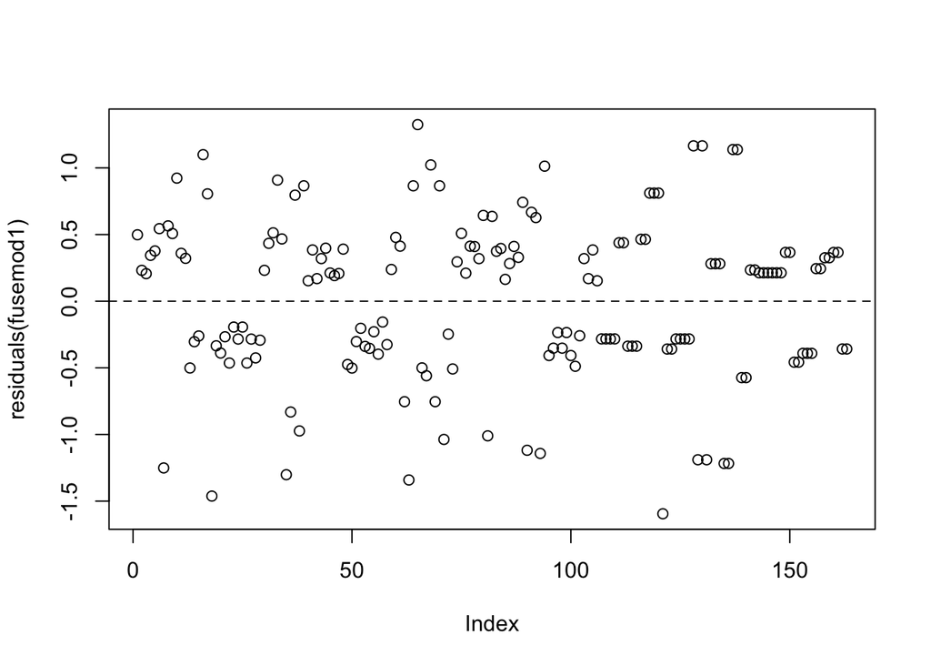

```
## integer(0)
```

```r
plot(residuals(fusemod1)) + abline(h=0, lty=2)
```

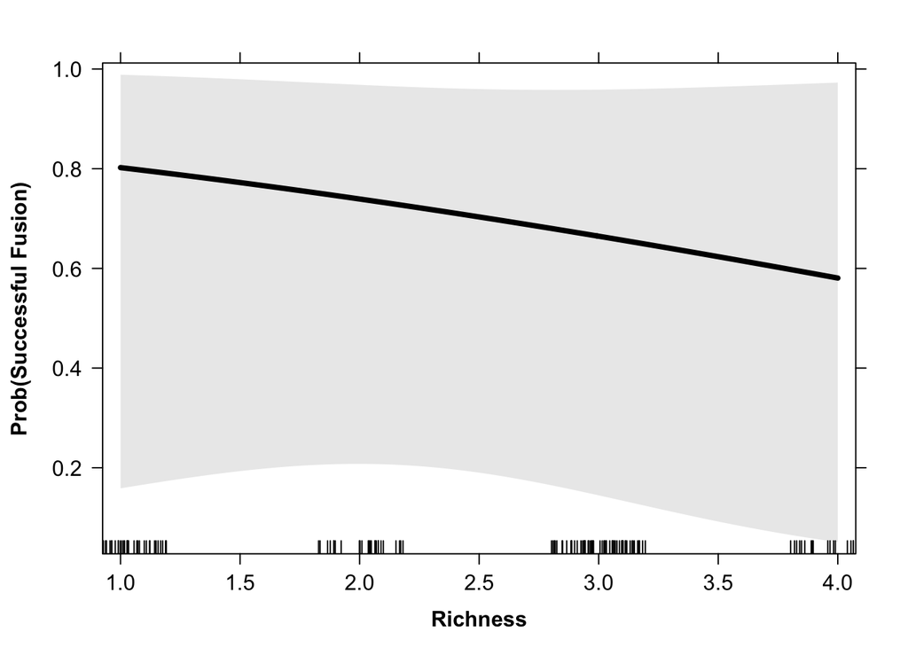

```r
eff.fuse1 <- predictorEffect("Richness", fusemod1, xlevels=4, rug=TRUE)
fuse.effects1<-plot(eff.fuse1,
                   lines=list(multiline=TRUE,
                              col=c("black"),
                              lty=1),
                   confint=list(style="bands", alpha=0.1),
                   lwd=4,
                   #axes=list(y=list(lim=c(0, 1))),
                   type="response",
                   ylab=expression(bold("Prob(Successful Fusion)")),
                   xlab=expression(bold("Richness")),
                   main="",
                   lattice=list(key.args=list(space="right",
                                              border=FALSE,
                                              title=expression(bold("Genotypic \nRichness")),
                                              cex=1,
                                              cex.title=1)));fuse.effects1
```

Generate a summary of proportion fused at the end of the grow-out period.

```r
meanfusion <- ddply(group_final, c("Richness"), summarise,
                   N    = length(Fusion[!is.na(Fusion)]),
                   mean = mean(Fusion, na.rm=TRUE),
                   sd   = sd(Fusion, na.rm=TRUE),
                   se   = sd / sqrt(N),
                   max = max(Fusion, na.rm=TRUE),
                   lower = mean-sd,
                   upper = mean+sd
                   )
meanfusion
```

```
##   Richness  N      mean        sd         se max       lower    upper
## 1        1 57 0.5263158 0.5037454 0.06672270   1  0.02257042 1.030061
## 2        2 26 0.6153846 0.4961389 0.09730085   1  0.11924568 1.111524
## 3        3 56 0.5357143 0.5032363 0.06724778   1  0.03247801 1.038951
## 4        4 24 0.5000000 0.5107539 0.10425721   1 -0.01075392 1.010754
```

## 3. GROW OUT GROWTH

### **Analysis**

Growth is measured as polyp expansion in each spat by number of spat in each sibling type and number of fused individuals. Growth is measured in final dataset as all spat started with 1 polyp each.

Analyze polyp expansion with the final dataset and present means.

```r
polypmod1<-glmer(Polyps ~ Richness + Community + Fusion.Partners + Richness:Fusion.Partners + (1|Parent.Site/Colony) + (1|Tank) + (1|Slide), data=final, family = poisson)
```

```
## boundary (singular) fit: see ?isSingular
```

```r
summary(polypmod1)
```

```
## Generalized linear mixed model fit by maximum likelihood (Laplace
##   Approximation) [glmerMod]
##  Family: poisson  ( log )
## Formula:
## Polyps ~ Richness + Community + Fusion.Partners + Richness:Fusion.Partners +
##     (1 | Parent.Site/Colony) + (1 | Tank) + (1 | Slide)
##    Data: final
##
##      AIC      BIC   logLik deviance df.resid
##    590.7    618.2   -286.4    572.7      148
##
## Scaled residuals:
##      Min       1Q   Median       3Q      Max
## -1.10224 -0.55740 -0.03806  0.43006  1.42031
##
## Random effects:
##  Groups             Name        Variance  Std.Dev.
##  Slide              (Intercept) 4.527e-09 6.728e-05
##  Colony:Parent.Site (Intercept) 7.002e-02 2.646e-01
##  Parent.Site        (Intercept) 5.196e-03 7.208e-02
##  Tank               (Intercept) 7.883e-03 8.879e-02
## Number of obs: 157, groups:
## Slide, 92; Colony:Parent.Site, 21; Parent.Site, 6; Tank, 5
##
## Fixed effects:
##                           Estimate Std. Error z value Pr(>|z|)
## (Intercept)               1.245663   0.150290   8.288   <2e-16 ***
## Richness                  0.002656   0.089657   0.030    0.976
## CommunityGroup           -0.089969   0.174884  -0.514    0.607
## Fusion.Partners          -0.013179   0.168666  -0.078    0.938
## Richness:Fusion.Partners  0.014306   0.054978   0.260    0.795
## ---
## Signif. codes:  0 '***' 0.001 '**' 0.01 '*' 0.05 '.' 0.1 ' ' 1
##
## Correlation of Fixed Effects:
##             (Intr) Rchnss CmmntG Fsn.Pr
## Richness    -0.592
## CommuntyGrp  0.120 -0.689
## Fusn.Prtnrs -0.353  0.642 -0.711
## Rchnss:Fs.P  0.429 -0.768  0.656 -0.936
## convergence code: 0
## boundary (singular) fit: see ?isSingular
```

```r
Anova(polypmod1, type="II")
```

```
## Analysis of Deviance Table (Type II Wald chisquare tests)
##
## Response: Polyps
##                           Chisq Df Pr(>Chisq)
## Richness                 0.1281  1     0.7204
## Community                0.2647  1     0.6069
## Fusion.Partners          0.2204  1     0.6387
## Richness:Fusion.Partners 0.0677  1     0.7947
```

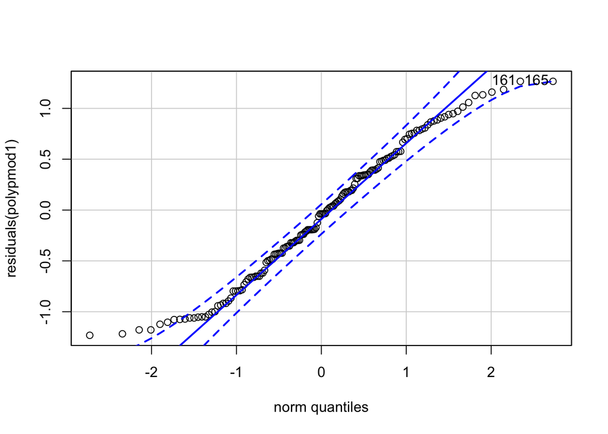

```
## 161 165
##  32  33
```

```r
qqPlot(residuals(polypmod1))
```

```r
meangrowth <- ddply(final, c("Community"), summarise,
                   N    = length(Polyps[!is.na(Polyps)]),
                   mean = mean(Polyps, na.rm=TRUE),
                   sd   = sd(Polyps, na.rm=TRUE),
                   se   = sd / sqrt(N),
                   max = max(Polyps, na.rm=TRUE),
                   lower = mean-sd,
                   upper = mean+sd
                   )
meangrowth
```

```
##    Community   N     mean       sd        se max    lower    upper
## 1 Individual  45 3.533333 1.778661 0.2651472   8 1.754672 5.311995
## 2      Group 112 3.357143 1.558800 0.1472928   7 1.798343 4.915943
```

Plot the model outputs.

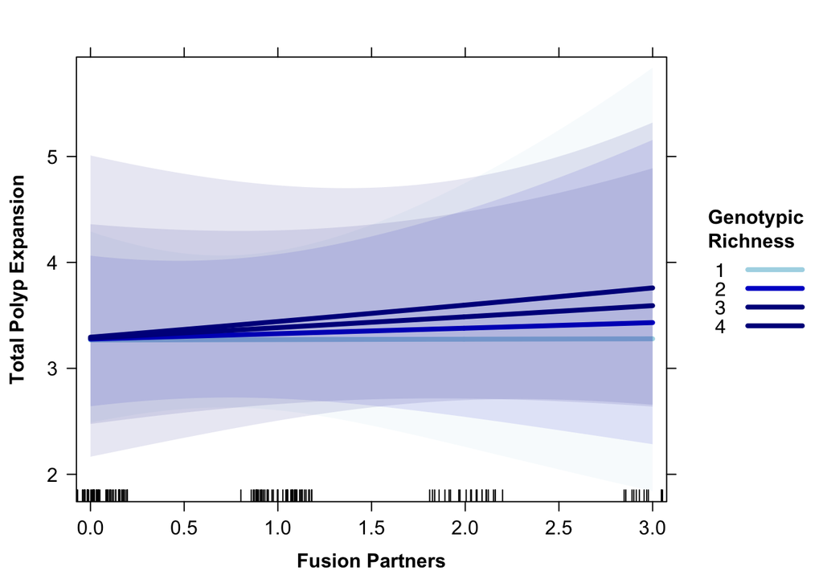

```r
eff.polyps1 <- predictorEffect("Fusion.Partners", polypmod1, xlevels=4, rug=TRUE)
polyp.effects1<-plot(eff.polyps1,
                   lines=list(multiline=TRUE,
                              col=c("lightblue","mediumblue", "blue4", "darkblue"),
                              lty=1),
                   confint=list(style="bands", alpha=0.1),
                   lwd=4,
                   #axes=list(y=list(lim=c(0, 1))),
                   type="response",
                   ylab=expression(bold("Total Polyp Expansion")),
                   legend.position="right",
                   xlab=expression(bold("Fusion Partners")),
                   main="",
                   lattice=list(key.args=list(space="right",
                                              border=FALSE,
                                              title=expression(bold("Genotypic \nRichness")),
                                              cex=1,
                                              cex.title=1)));polyp.effects1
```

Combine figures for Grow-Out Period.

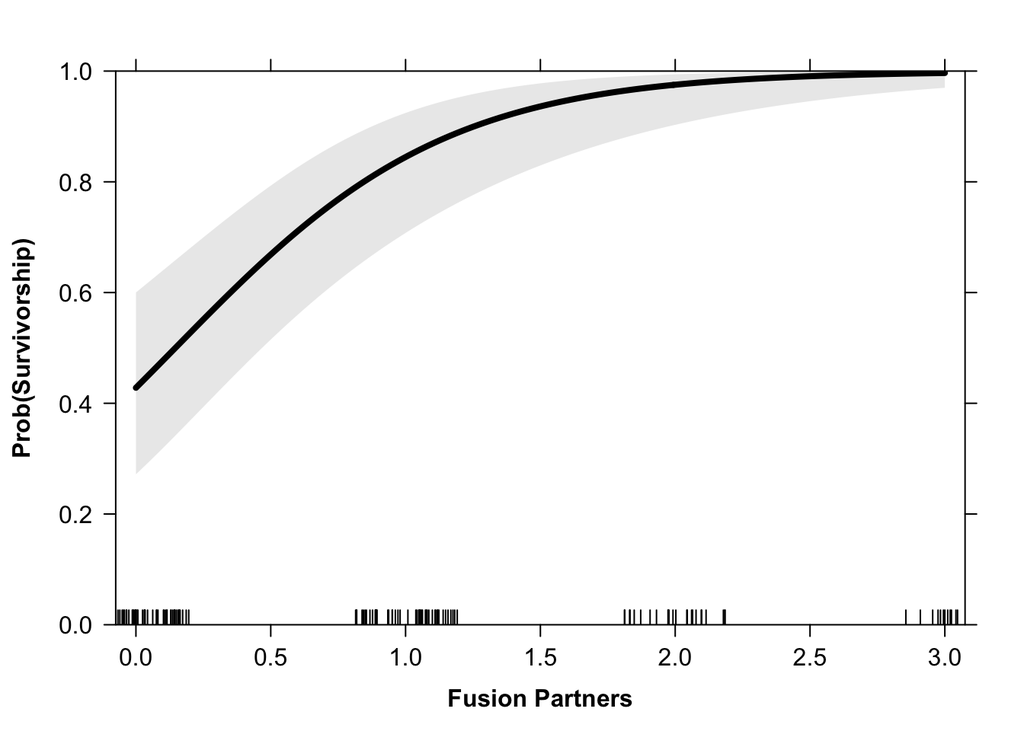

```r
grow_out_figs<-plot_grid(surv.effects2b, labels = c(""), ncol=1, nrow=1, rel_heights= c(1), rel_widths = c(1), label_size = 20, label_y=1, align="h");grow_out_figs
```

```r
ggsave(filename="Figures/grow_out_figs.png", plot=grow_out_figs, dpi=500, width=8, height=8, units="in")
```

## 4. STRESS SURVIVORSHIP

### **Load data**

Survivorship is measured as binary on each individual spat in the experiment.

```r
#load data
stress<-read.csv("Data/Stress_Responses_PostGenotyping.csv", header=TRUE, sep=",", na.strings="NA")
stress$Diversity.Type<-relevel(stress$Diversity.Type, ref="Individual")
stress$Community<-relevel(stress$Community, ref="Individual")
stress$Polyps<-as.numeric(stress$Polyps)
stress$Fusion.Type<-relevel(stress$Fusion.Type, ref="Not Fused")
stress$Richness.Type<-relevel(stress$Richness.Type, ref="Single")

#remove non-fused from analysis
stressdrop<-droplevels(stress[!stress$Fusion.Type == 'Not Fused',])
```

Subset the final timepoint, “group” juvenile datasets for additional analyses.

```r
final_stress<-stress[which(stress$Timepoint == "End"),]
final_stress_drop<-stressdrop[which(stressdrop$Timepoint == "End"),]
group_stress<-stress[which(stress$Community == "Group"),]
group_final_stress<-group_stress[which(group_stress$Timepoint == "End"),]
group_d26_stress<-group_stress[which(group_stress$Timepoint == "S2D11"),]
d26_stress<-stress[which(stress$Timepoint == "S2D11"),]
d23_stress<-stress[which(stress$Timepoint == "S2D8"),]
```

### **Analysis**

Analyze with a logistic binomial regression model.

Analyze survivorship during the stress test as survivorship as a function of fusion status and genotypic richness. Fusion is classified as “Fused” or “Not Fused” at the beginning of the stress test. Genotypic richness is classified as “single” genotype or “multiple” genotypes. This is to maximize sample size due to mortality and low sample size within levels of fusion partners and genotypic richness. Individuals are referred to as “individuals”.

First, examine sample size of groups. As there were very few “not fused” individuals in group juvenile slides, these will be removed from the analysis. We will only analyze survivorship of “individuals” and those which are “fused”. We will then examine the differences between “single” and “multiple” genotype groups.

```r
meanstresssurv1 <- ddply(stress, c("Fusion.Type", "Diversity.Type", "Day", "Treatment"), summarise,
                   N    = length(Survivorship[!is.na(Survivorship)]),
                   mean = mean(Survivorship, na.rm=TRUE),
                   sd   = sd(Survivorship, na.rm=TRUE),
                   se   = sd / sqrt(N),
                   max = max(Survivorship, na.rm=TRUE),
                   lower = mean-sd,
                   upper = mean+sd
                   )
meanstresssurv1
```

```
##    Fusion.Type Diversity.Type Day Treatment  N       mean        sd         se
## 1    Not Fused       Non-Self   0   Ambient  1 1.00000000        NA         NA
## 2    Not Fused       Non-Self   0      High  9 1.00000000 0.0000000 0.00000000
## 3    Not Fused       Non-Self   3   Ambient  1 1.00000000        NA         NA
## 4    Not Fused       Non-Self   3      High  9 1.00000000 0.0000000 0.00000000
## 5    Not Fused       Non-Self  11   Ambient  1 1.00000000        NA         NA
## 6    Not Fused       Non-Self  11      High  9 1.00000000 0.0000000 0.00000000
## 7    Not Fused       Non-Self  17   Ambient  1 1.00000000        NA         NA
## 8    Not Fused       Non-Self  17      High  9 1.00000000 0.0000000 0.00000000
## 9    Not Fused       Non-Self  23   Ambient  1 1.00000000        NA         NA
## 10   Not Fused       Non-Self  23      High  9 1.00000000 0.0000000 0.00000000
## 11   Not Fused       Non-Self  26   Ambient  1 1.00000000        NA         NA
## 12   Not Fused       Non-Self  26      High  9 0.33333333 0.5000000 0.16666667
## 13   Not Fused       Non-Self  32   Ambient  1 1.00000000        NA         NA
## 14   Not Fused       Non-Self  32      High  9 0.00000000 0.0000000 0.00000000
```

[output cut: 127 more lines]

Display means with the not fused group removed.

```r
meanstresssurv2 <- ddply(stressdrop, c("Fusion.Type", "Diversity.Type", "Day", "Treatment"), summarise,
                   N    = length(Survivorship[!is.na(Survivorship)]),
                   mean = mean(Survivorship, na.rm=TRUE),
                   sd   = sd(Survivorship, na.rm=TRUE),
                   se   = sd / sqrt(N),
                   max = max(Survivorship, na.rm=TRUE),
                   lower = mean-sd,
                   upper = mean+sd
                   )
meanstresssurv2
```

```
##    Fusion.Type Diversity.Type Day Treatment  N       mean        sd         se
## 1        Fused       Non-Self   0   Ambient 25 1.00000000 0.0000000 0.00000000
## 2        Fused       Non-Self   0      High 32 1.00000000 0.0000000 0.00000000
## 3        Fused       Non-Self   3   Ambient 29 1.00000000 0.0000000 0.00000000
## 4        Fused       Non-Self   3      High 32 1.00000000 0.0000000 0.00000000
## 5        Fused       Non-Self  11   Ambient 29 1.00000000 0.0000000 0.00000000
## 6        Fused       Non-Self  11      High 32 1.00000000 0.0000000 0.00000000
## 7        Fused       Non-Self  17   Ambient 29 1.00000000 0.0000000 0.00000000
## 8        Fused       Non-Self  17      High 32 0.96875000 0.1767767 0.03125000
## 9        Fused       Non-Self  23   Ambient 29 1.00000000 0.0000000 0.00000000
## 10       Fused       Non-Self  23      High 32 0.90625000 0.2961446 0.05235146
## 11       Fused       Non-Self  26   Ambient 29 0.89655172 0.3099340 0.05755331
## 12       Fused       Non-Self  26      High 32 0.37500000 0.4918694 0.08695104
## 13       Fused       Non-Self  32   Ambient 29 0.82758621 0.3844259 0.07138609
## 14       Fused       Non-Self  32      High 32 0.09375000 0.2961446 0.05235146
```

[output cut: 71 more lines]

Now that the “not fused” group is removed, analyze the effect of richness, fusion, and treatment on survivorship over the course of the stress test. Note that there is no interaction between richness type and fusion type as individual juveniles are not exposed to other juveniles and therefore no option for genotypic richness.

```r
stressmod1<-glmer(Survivorship ~ Day + Treatment + Fusion.Type + Richness.Type + Day:Treatment + Day:Fusion.Type + Day:Richness.Type + Day:Treatment:Fusion.Type + Day:Treatment:Richness.Type + Treatment:Fusion.Type + Treatment:Richness.Type + (1|Parent.Site/Colony) + (1|Treatment:Tank) + (1|Slide), data=stressdrop, family=binomial, link=logit)
summary(stressmod1)
```

```
## Generalized linear mixed model fit by maximum likelihood (Laplace
##   Approximation) [glmerMod]
##  Family: binomial  ( logit )
## Formula: Survivorship ~ Day + Treatment + Fusion.Type + Richness.Type +
##     Day:Treatment + Day:Fusion.Type + Day:Richness.Type + Day:Treatment:Fusion.Type +
##     Day:Treatment:Richness.Type + Treatment:Fusion.Type + Treatment:Richness.Type +
##     (1 | Parent.Site/Colony) + (1 | Treatment:Tank) + (1 | Slide)
##    Data: stressdrop
##
##      AIC      BIC   logLik deviance df.resid
##    329.1    406.9   -148.5    297.1      939
##
## Scaled residuals:
##     Min      1Q  Median      3Q     Max
## -5.5355  0.0000  0.0080  0.0552  3.6904
##
## Random effects:
##  Groups             Name        Variance  Std.Dev.
##  Slide              (Intercept) 7.063e+00 2.657546
##  Colony:Parent.Site (Intercept) 1.969e+00 1.403068
##  Treatment:Tank     (Intercept) 2.337e-03 0.048346
##  Parent.Site        (Intercept) 3.134e-05 0.005598
## Number of obs: 955, groups:
## Slide, 81; Colony:Parent.Site, 20; Treatment:Tank, 9; Parent.Site, 6
##
## Fixed effects:
##                                          Estimate Std. Error z value Pr(>|z|)
## (Intercept)                              14.63454    6.10415   2.397  0.01651
## Day                                      -0.39202    0.19337  -2.027  0.04263
## TreatmentHigh                            56.36341   19.98126   2.821  0.00479
## Fusion.TypeIndividual                    -5.30817    6.35869  -0.835  0.40384
## Richness.TypeMultiple                     0.16612    7.19877   0.023  0.98159
## Day:TreatmentHigh                        -2.49569    0.81814  -3.050  0.00229
## Day:Fusion.TypeIndividual                 0.27564    0.20589   1.339  0.18065
## Day:Richness.TypeMultiple                 0.02751    0.23123   0.119  0.90530
## TreatmentHigh:Fusion.TypeIndividual     -55.36799   20.10411  -2.754  0.00589
## TreatmentHigh:Richness.TypeMultiple     -53.28735   20.64455  -2.581  0.00985
## Day:TreatmentHigh:Fusion.TypeIndividual   2.11134    0.79558   2.654  0.00796
## Day:TreatmentHigh:Richness.TypeMultiple   2.17177    0.82262   2.640  0.00829
##
```

[output cut: 30 more lines]

```
## TreatmntHgh
## Fsn.TypIndv
## Rchnss.TypM
## Dy:TrtmntHg
## Dy:Fsn.TypI
## Dy:Rchns.TM
## TrtmnH:F.TI
## TrtmnH:R.TM
## Dy:TrH:F.TI -0.957
## Dy:TrH:R.TM -0.991  0.970
## convergence code: 0
## Model failed to converge with max|grad| = 0.289659 (tol = 0.001, component 1)
## Model is nearly unidentifiable: large eigenvalue ratio
##  - Rescale variables?
## failure to converge in 10000 evaluations
```

```r
Anova(stressmod1, type="II")
```

```
## Analysis of Deviance Table (Type II Wald chisquare tests)
##
## Response: Survivorship
##                               Chisq Df Pr(>Chisq)
## Day                         22.1809  1  2.481e-06 ***
## Treatment                   11.8531  1  0.0005756 ***
## Fusion.Type                  0.3768  1  0.5393341
## Richness.Type                0.2439  1  0.6213956
## Day:Treatment               11.4931  1  0.0006985 ***
## Day:Fusion.Type              4.6319  1  0.0313830 *
## Day:Richness.Type            0.9536  1  0.3288031
## Treatment:Fusion.Type        0.8606  1  0.3535800
## Treatment:Richness.Type      0.0688  1  0.7930961
## Day:Treatment:Fusion.Type    7.0429  1  0.0079582 **
## Day:Treatment:Richness.Type  6.9699  1  0.0082893 **
## ---
## Signif. codes:  0 '***' 0.001 '**' 0.01 '*' 0.05 '.' 0.1 ' ' 1
```

```r
dispersion_glmer(stressmod1) #no overdispersion
```

```
## [1] 0.455883
```

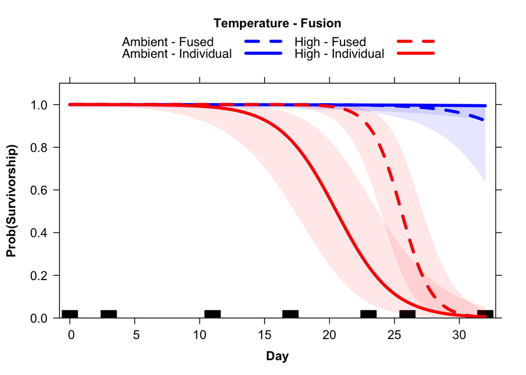

```r
#generate model for effect plot
stressdrop$group<-paste(stressdrop$Treatment, "-", stressdrop$Fusion.Type)

stressmod2<-glmer(Survivorship ~ Day * group + (1|Parent.Site/Colony) + (1|Treatment:Tank) + (1|Slide), data=stressdrop, family=binomial, link=logit)
eff.stress2 <- predictorEffect(c("Day"), stressmod2)

stress.effectsFUSE<-plot(eff.stress2,
                   lines=list(multiline=TRUE,
                              col=c("blue", "blue", "red", "red"),
                              lty=c(2,1,2,1)),
                   confint=list(style="bands", alpha=0.1),
                   lwd=4,
                   axes=list(y=list(lim=c(0, 1.1))),
                   type="response",
                   ylab=expression(bold("Prob(Survivorship)")),
                   legend.position="top",
                   xlab=expression(bold("Day")),
                   main="",
                   lattice=list(key.args=list(space="top",
                                              border=FALSE,
                                              title=expression(bold("Temperature - Fusion")),
                                              cex=1,
                                              cex.title=1)));stress.effectsFUSE
```

Obtain effect summary for effects of fusion.

```r
summary(effect(c("Day", "group"), xlevels=50, stressmod2))
```

```
## NOTE: Daygroup is not a high-order term in the model
```

```
##
##  Day*group effect
##        group
## Day     Ambient - Fused Ambient - Individual High - Fused High - Individual
##   0           0.9999993            0.9997977  1.000000000       0.999920761
##   0.653       0.9999992            0.9997835  1.000000000       0.999892992
##   1.31        0.9999989            0.9997683  0.999999999       0.999855229
##   1.96        0.9999987            0.9997521  0.999999999       0.999804770
##   2.61        0.9999983            0.9997349  0.999999997       0.999736729
##   3.27        0.9999978            0.9997161  0.999999996       0.999643346
##   3.92        0.9999972            0.9996964  0.999999992       0.999519074
##   4.57        0.9999965            0.9996752  0.999999986       0.999351528
##   5.22        0.9999956            0.9996526  0.999999976       0.999125662
##   5.88        0.9999943            0.9996280  0.999999957       0.998815791
##   6.53        0.9999928            0.9996021  0.999999925       0.998403625
##   7.18        0.9999909            0.9995744  0.999999869       0.997848312
##   7.84        0.9999884            0.9995443  0.999999768       0.997087058
##   8.49        0.9999852            0.9995126  0.999999593       0.996075568
##   9.14        0.9999812            0.9994787  0.999999286       0.994714709
##   9.8         0.9999761            0.9994418  0.999998738       0.992852745
##   10.4        0.9999702            0.9994061  0.999997882       0.990601726
##   11.1        0.9999615            0.9993614  0.999996124       0.987076596
##   11.8        0.9999502            0.9993134  0.999992907       0.982252939
##   12.4        0.9999379            0.9992695  0.999988093       0.976741728
##   13.1        0.9999198            0.9992146  0.999978210       0.968184918
##   13.7        0.9999000            0.9991642  0.999963422       0.958489616
##   14.4        0.9998707            0.9991014  0.999933062       0.943605490
##   15          0.9998389            0.9990439  0.999887638       0.926984754
##   15.7        0.9997917            0.9989721  0.999794391       0.901959599
##   16.3        0.9997404            0.9989062  0.999654898       0.874694789
##   17          0.9996644            0.9988241  0.999368629       0.834939031
##   17.6        0.9995817            0.9987488  0.998940587       0.793307097
##   18.3        0.9994592            0.9986548  0.998062933       0.735536615
##   18.9        0.9993261            0.9985686  0.996752561       0.678487579
##   19.6        0.9991289            0.9984612  0.994073022       0.604619616
##   20.2        0.9989145            0.9983627  0.990090386       0.537102601
##   20.9        0.9985969            0.9982398  0.982012930       0.456759520
##   21.6        0.9981866            0.9981076  0.967567109       0.378604925
##   22.2        0.9977409            0.9979865  0.946728273       0.316145778
##   22.9        0.9970811            0.9978355  0.906638674       0.250937202
```

[output cut: 107 more lines]

```
##   22.9        0.9997590            0.9998408   0.97726698        0.57999993
##   23.5        0.9996750            0.9998286   0.95973281        0.51987255
##   24.2        0.9995416            0.9998137   0.92450064        0.45116964
##   24.8        0.9993875            0.9998004   0.87606264        0.39519262
##   25.5        0.9991464            0.9997844   0.79274489        0.33481062
##   26.1        0.9988722            0.9997703   0.69819553        0.28804822
##   26.8        0.9984510            0.9997535   0.56918951        0.23973322
##   27.4        0.9979811            0.9997388   0.45491727        0.20365760
##   28.1        0.9972741            0.9997215   0.33278456        0.16747689
##   28.7        0.9965024            0.9997065   0.24573591        0.14111431
##   29.4        0.9953683            0.9996890   0.16748535        0.11518060
##   30          0.9941597            0.9996740   0.11853643        0.09657472
##   30.7        0.9924266            0.9996566   0.07823932        0.07848815
##   31.3        0.9906238            0.9996419   0.05447084        0.06563258
##   32          0.9880994            0.9996250   0.03557907        0.05322269
```

The curves for high temperature meet 50% at the following timepoints:

50% mortality (LT50) is approximately 5 days later for fused corals than for individuals in this stress test.

Next plot the effect of genotypic richness within the fused corals.

```r
stressdrop$group<-paste(stressdrop$Treatment, "-", stressdrop$Richness.Type)

stressmod3<-glmer(Survivorship ~ Day * group + (1|Parent.Site/Colony) + (1|Treatment:Tank) + (1|Slide), data=stressdrop, family=binomial, link=logit, subset=c(Fusion.Type=="Fused"))
```

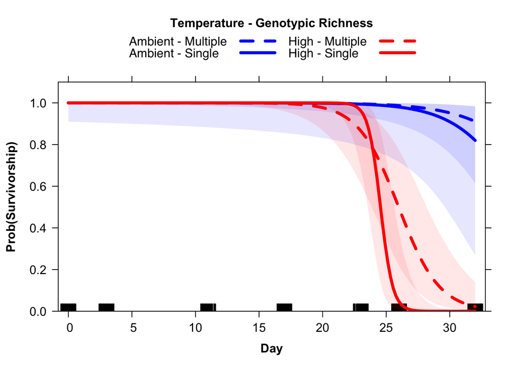

```r
eff.stress3 <- predictorEffect(c("Day"), stressmod3)
stress.effectsRICHNESS<-plot(eff.stress3,
                   lines=list(multiline=TRUE,
                              col=c("blue", "blue", "red", "red"),
                              lty=c(2,1,2,1)),
                   confint=list(style="bands", alpha=0.1),
                   lwd=4,
                   axes=list(y=list(lim=c(0, 1.1))),
                   type="response",
                   ylab=expression(bold("Prob(Survivorship)")),
                   legend.position="top",
                   xlab=expression(bold("Day")),
                   main="",
                   lattice=list(key.args=list(space="top",
                                              border=FALSE,
                                              title=expression(bold("Temperature - Genotypic Richness")),
                                              cex=1,
                                              cex.title=1)));stress.effectsRICHNESS
```

Obtain effect summary for effects of richness.

```r
summary(effect(c("Day", "group"), xlevels=50, stressmod3))
```

```
## NOTE: Daygroup is not a high-order term in the model
```

```
##
##  Day*group effect
##        group
## Day     Ambient - Multiple Ambient - Single High - Multiple High - Single
##   0              0.9999977        0.9999993      0.99999991  1.000000e+00
##   0.653          0.9999971        0.9999991      0.99999987  1.000000e+00
##   1.31           0.9999964        0.9999988      0.99999980  1.000000e+00
##   1.96           0.9999955        0.9999985      0.99999971  1.000000e+00
##   2.61           0.9999945        0.9999980      0.99999956  1.000000e+00
##   3.27           0.9999931        0.9999974      0.99999933  1.000000e+00
##   3.92           0.9999914        0.9999967      0.99999900  1.000000e+00
##   4.57           0.9999894        0.9999957      0.99999850  1.000000e+00
##   5.22           0.9999868        0.9999944      0.99999774  1.000000e+00
##   5.88           0.9999835        0.9999927      0.99999658  1.000000e+00
##   6.53           0.9999796        0.9999906      0.99999487  1.000000e+00
##   7.18           0.9999746        0.9999879      0.99999229  1.000000e+00
##   7.84           0.9999684        0.9999843      0.99998834  1.000000e+00
##   8.49           0.9999608        0.9999796      0.99998249  1.000000e+00
##   9.14           0.9999513        0.9999737      0.99997369  1.000000e+00
##   9.8            0.9999393        0.9999659      0.99996022  1.000000e+00
##   10.4           0.9999259        0.9999567      0.99994208  1.000000e+00
##   11.1           0.9999065        0.9999429      0.99991022  1.000000e+00
##   11.8           0.9998820        0.9999248      0.99986084  1.000000e+00
##   12.4           0.9998559        0.9999046      0.99979738  1.000000e+00
##   13.1           0.9998181        0.9998743      0.99968595  1.000000e+00
##   13.7           0.9997779        0.9998406      0.99954278  1.000000e+00
##   14.4           0.9997196        0.9997899      0.99929142  1.000000e+00
##   15             0.9996577        0.9997337      0.99896859  1.000000e+00
##   15.7           0.9995679        0.9996489      0.99840206  1.000000e+00
##   16.3           0.9994724        0.9995550      0.99767499  1.000000e+00
##   17             0.9993341        0.9994134      0.99640047  9.999999e-01
##   17.6           0.9991870        0.9992566      0.99476746  9.999995e-01
##   18.3           0.9989740        0.9990201      0.99191200  9.999978e-01
##   18.9           0.9987475        0.9987583      0.98826665  9.999923e-01
##   19.6           0.9984194        0.9983634      0.98192808  9.999669e-01
##   20.2           0.9980707        0.9979266      0.97390127  9.998845e-01
##   20.9           0.9975658        0.9972680      0.96011546  9.995041e-01
##   21.6           0.9969291        0.9964009      0.93950012  9.978738e-01
##   22.2           0.9962529        0.9954427      0.91427374  9.926240e-01
##   22.9           0.9952745        0.9939998      0.87309577  9.690742e-01
```

[output cut: 107 more lines]

```
##   22.9           0.9996605        0.9998595       0.9661436   0.997429924
##   23.5           0.9995416        0.9997887       0.9484020   0.986724642
##   24.2           0.9993529        0.9996628       0.9179433   0.930000095
##   24.8           0.9991349        0.9995010       0.8813345   0.795284603
##   25.5           0.9987947        0.9992209       0.8245766   0.550120563
##   26.1           0.9984092        0.9988717       0.7638259   0.348617081
##   26.8           0.9978206        0.9982892       0.6810723   0.185306519
##   27.4           0.9971697        0.9975933       0.6035272   0.103263314
##   28.1           0.9962028        0.9964888       0.5108857   0.051167713
##   28.7           0.9951651        0.9952403       0.4340329   0.027886805
##   29.4           0.9936730        0.9933794       0.3515915   0.013743629
##   30             0.9921254        0.9914119       0.2892273   0.007512044
##   30.7           0.9899784        0.9886799       0.2271676   0.003725557
##   31.3           0.9878292        0.9859890       0.1829900   0.002048208
##   32             0.9849503        0.9825025       0.1410353   0.001022190
```

## 5. STRESS FUSION

### **Analysis**

Analyze with a logistic binomial regression model.

Analyze fusion success by the end of the stress test within fused corals by treatment and genotypic richness.

```r
stressfuse1<-glmer(Fusion ~ Treatment * Richness.Type + (1|Parent.Site/Colony) + (1|Treatment:Tank) + (1|Slide), data=final_stress_drop, family=binomial, link=logit, subset=c(Fusion.Type=="Fused"))
```

```
## boundary (singular) fit: see ?isSingular
```

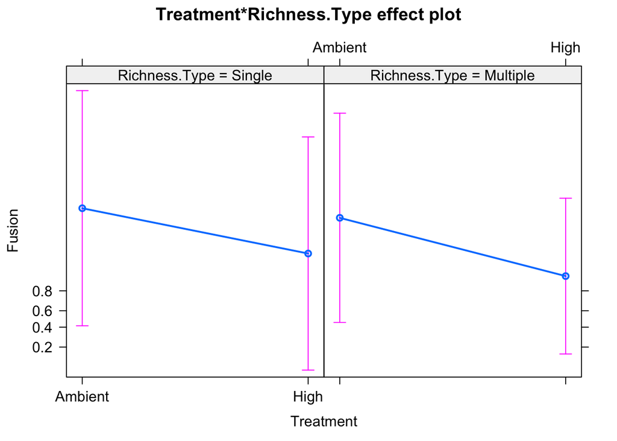

```r
summary(stressfuse1)
Anova(stressfuse1, type="II")

plot(allEffects(stressfuse1))
```

[output not shown]

```r
dispersion_glmer(stressfuse1) #no overdispersion
```

```r
meanstressfuse <- ddply(final_stress_drop, c("Treatment", "Richness.Type"), summarise,
                   N    = length(Fusion[!is.na(Fusion)]),
                   mean = mean(Fusion, na.rm=TRUE),
                   sd   = sd(Fusion, na.rm=TRUE),
                   se   = sd / sqrt(N),
                   max = max(Fusion, na.rm=TRUE),
                   lower = mean-sd,
                   upper = mean+sd
                   )
meanstressfuse
```

```
##   Treatment Richness.Type  N      mean        sd         se max     lower
## 1   Ambient        Single 12 0.9166667 0.2886751 0.08333333   1 0.6279915
## 2   Ambient      Multiple 29 0.8620690 0.3509312 0.06516629   1 0.5111378
## 3      High        Single 19 0.7368421 0.4524139 0.10379087   1 0.2844282
## 4      High      Multiple 32 0.7187500 0.4568034 0.08075220   1 0.2619466
##      upper
## 1 1.205342
## 2 1.213000
## 3 1.189256
## 4 1.175553
```

There is no effect of treatment or richness on fusion sucess. There is a trend for slightly lower fusion in high temperature, but this was not significant.

## 6. STRESS GROWTH

Analyze with a poisson regression model.

Analyze growth as polyp expansion at day 23 of 32 of the stress test. Due to high mortality, this is the last time point with suffficient sample size to measure growth.

Display mean values. Day 23 has sufficient sample size.

```r
meanstressgrowth <- ddply(stressdrop, c("Day", "Treatment", "Fusion.Type", "Richness.Type"), summarise,
                   N    = length(Polyps[!is.na(Polyps)]),
                   mean = mean(Polyps, na.rm=TRUE),
                   sd   = sd(Polyps, na.rm=TRUE),
                   se   = sd / sqrt(N),
                   max = max(Polyps, na.rm=TRUE),
                   lower = mean-sd,
                   upper = mean+sd
                   )
meanstressgrowth
```

```
##    Day Treatment Fusion.Type Richness.Type  N      mean        sd        se
## 1    0   Ambient       Fused        Single 12  5.000000 1.1281521 0.3256695
## 2    0   Ambient       Fused      Multiple 25  5.200000 2.1015867 0.4203173
## 3    0   Ambient  Individual        Single 22  5.727273 2.3336425 0.4975343
## 4    0      High       Fused        Single 19  5.473684 1.1239030 0.2578410
## 5    0      High       Fused      Multiple 32  5.500000 1.9007639 0.3360108
## 6    0      High  Individual        Single 23  5.000000 1.8340219 0.3824200
## 7    3   Ambient       Fused        Single 12  5.500000 1.0000000 0.2886751
## 8    3   Ambient       Fused      Multiple 29  6.172414 1.8529699 0.3440879
## 9    3   Ambient  Individual        Single 21  6.285714 2.0528726 0.4479735
## 10   3      High       Fused        Single 18  6.055556 0.9983647 0.2353168
## 11   3      High       Fused      Multiple 32  5.906250 1.8024960 0.3186393
## 12   3      High  Individual        Single 24  5.833333 1.3077251 0.2669383
## 13  11   Ambient       Fused        Single 12  5.666667 1.0730867 0.3097735
## 14  11   Ambient       Fused      Multiple 29  6.206897 1.8396294 0.3416106
```

[output cut: 71 more lines]

Analyze the effect of temperature, fusion, and genotypic richness on polyp expansion at day 23.

```r
stresspolypmod1<-glmer(Polyps ~ Treatment + Richness.Type + Fusion.Type + Treatment:Richness.Type + Treatment:Fusion.Type + (1|Parent.Site/Colony) + (1|Treatment:Tank) + (1|Slide), data=stressdrop, family = poisson, subset=c(Timepoint=="S2D8"))
```

```
## boundary (singular) fit: see ?isSingular
```

```r
summary(stresspolypmod1)
```

```
## Generalized linear mixed model fit by maximum likelihood (Laplace
##   Approximation) [glmerMod]
##  Family: poisson  ( log )
## Formula:
## Polyps ~ Treatment + Richness.Type + Fusion.Type + Treatment:Richness.Type +
##     Treatment:Fusion.Type + (1 | Parent.Site/Colony) + (1 | Treatment:Tank) +
##     (1 | Slide)
##    Data: stressdrop
##  Subset: c(Timepoint == "S2D8")
##
##      AIC      BIC   logLik deviance df.resid
##    537.1    565.2   -258.6    517.1      112
##
## Scaled residuals:
##      Min       1Q   Median       3Q      Max
## -2.12131 -0.41754  0.00512  0.46004  1.49711
##
## Random effects:
##  Groups             Name        Variance  Std.Dev.
##  Slide              (Intercept) 2.480e-09 4.980e-05
##  Colony:Parent.Site (Intercept) 6.042e-03 7.773e-02
##  Treatment:Tank     (Intercept) 9.451e-09 9.722e-05
##  Parent.Site        (Intercept) 1.409e-08 1.187e-04
## Number of obs: 122, groups:
## Slide, 72; Colony:Parent.Site, 20; Treatment:Tank, 8; Parent.Site, 6
##
## Fixed effects:
##                                     Estimate Std. Error z value Pr(>|z|)
## (Intercept)                          1.88982    0.12770  14.799   <2e-16 ***
## TreatmentHigh                       -0.20874    0.17045  -1.225    0.221
## Richness.TypeMultiple                0.02787    0.14665   0.190    0.849
## Fusion.TypeIndividual                0.04803    0.15485   0.310    0.756
## TreatmentHigh:Richness.TypeMultiple  0.06681    0.19939   0.335    0.738
## TreatmentHigh:Fusion.TypeIndividual  0.10272    0.21774   0.472    0.637
## ---
## Signif. codes:  0 '***' 0.001 '**' 0.01 '*' 0.05 '.' 0.1 ' ' 1
##
## Correlation of Fixed Effects:
##             (Intr) TrtmnH Rch.TM Fsn.TI TH:R.T
## TreatmntHgh -0.750
## Rchnss.TypM -0.861  0.658
## Fsn.TypIndv -0.818  0.628  0.725
## TrtmnH:R.TM  0.631 -0.850 -0.728 -0.525
## TrtmnH:F.TI  0.600 -0.793 -0.529 -0.721  0.672
## convergence code: 0
## boundary (singular) fit: see ?isSingular
```

```r
Anova(stresspolypmod1, type="II")
```

```
## Analysis of Deviance Table (Type II Wald chisquare tests)
##
## Response: Polyps
##                          Chisq Df Pr(>Chisq)
## Treatment               3.7598  1     0.0525 .
## Richness.Type           0.4007  1     0.5268
## Fusion.Type             0.8796  1     0.3483
## Treatment:Richness.Type 0.1123  1     0.7376
## Treatment:Fusion.Type   0.2226  1     0.6371
## ---
## Signif. codes:  0 '***' 0.001 '**' 0.01 '*' 0.05 '.' 0.1 ' ' 1
```

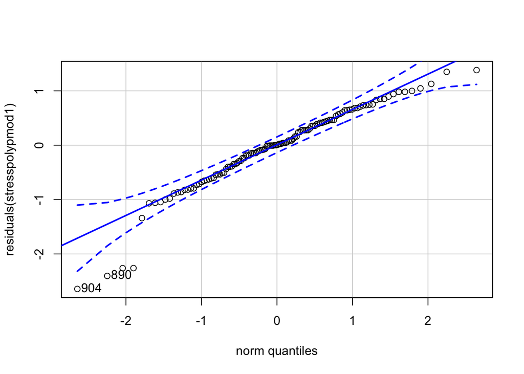

```
## 904 890
## 103 101
```

```r
qqPlot(residuals(stresspolypmod1))
```

There is no effect of treatment, fusion or genotypic richness on growth. Treatment is near significant at p=0.0525.

Generate a plot of polyp expansion by temperature treatment.

```r
stresspolypmod2<-glmer(Polyps ~ Treatment + (1|Parent.Site/Colony) + (1|Treatment:Tank) + (1|Slide), data=stressdrop, family = poisson, subset=c(Timepoint=="S2D8"))
```

```
## boundary (singular) fit: see ?isSingular
```

```r
summary(stresspolypmod2)
```

```
## Generalized linear mixed model fit by maximum likelihood (Laplace
##   Approximation) [glmerMod]
##  Family: poisson  ( log )
## Formula:
## Polyps ~ Treatment + (1 | Parent.Site/Colony) + (1 | Treatment:Tank) +
##     (1 | Slide)
##    Data: stressdrop
##  Subset: c(Timepoint == "S2D8")
##
##      AIC      BIC   logLik deviance df.resid
##    530.2    547.1   -259.1    518.2      116
##
## Scaled residuals:
##      Min       1Q   Median       3Q      Max
## -2.10222 -0.37801  0.05051  0.45027  1.55608
##
## Random effects:
##  Groups             Name        Variance  Std.Dev.
##  Slide              (Intercept) 0.000e+00 0.000e+00
##  Colony:Parent.Site (Intercept) 7.535e-03 8.680e-02
##  Treatment:Tank     (Intercept) 7.281e-10 2.698e-05
##  Parent.Site        (Intercept) 0.000e+00 0.000e+00
## Number of obs: 122, groups:
## Slide, 72; Colony:Parent.Site, 20; Treatment:Tank, 8; Parent.Site, 6
##
## Fixed effects:
##               Estimate Std. Error z value Pr(>|z|)
## (Intercept)    1.91816    0.05524  34.725   <2e-16 ***
## TreatmentHigh -0.15208    0.07352  -2.069   0.0386 *
## ---
## Signif. codes:  0 '***' 0.001 '**' 0.01 '*' 0.05 '.' 0.1 ' ' 1
##
## Correlation of Fixed Effects:
##             (Intr)
## TreatmntHgh -0.626
## convergence code: 0
## boundary (singular) fit: see ?isSingular
```

```r
Anova(stresspolypmod2, type="II")
```

```
## Analysis of Deviance Table (Type II Wald chisquare tests)
##
## Response: Polyps
##            Chisq Df Pr(>Chisq)
## Treatment 4.2792  1    0.03858 *
## ---
## Signif. codes:  0 '***' 0.001 '**' 0.01 '*' 0.05 '.' 0.1 ' ' 1
```

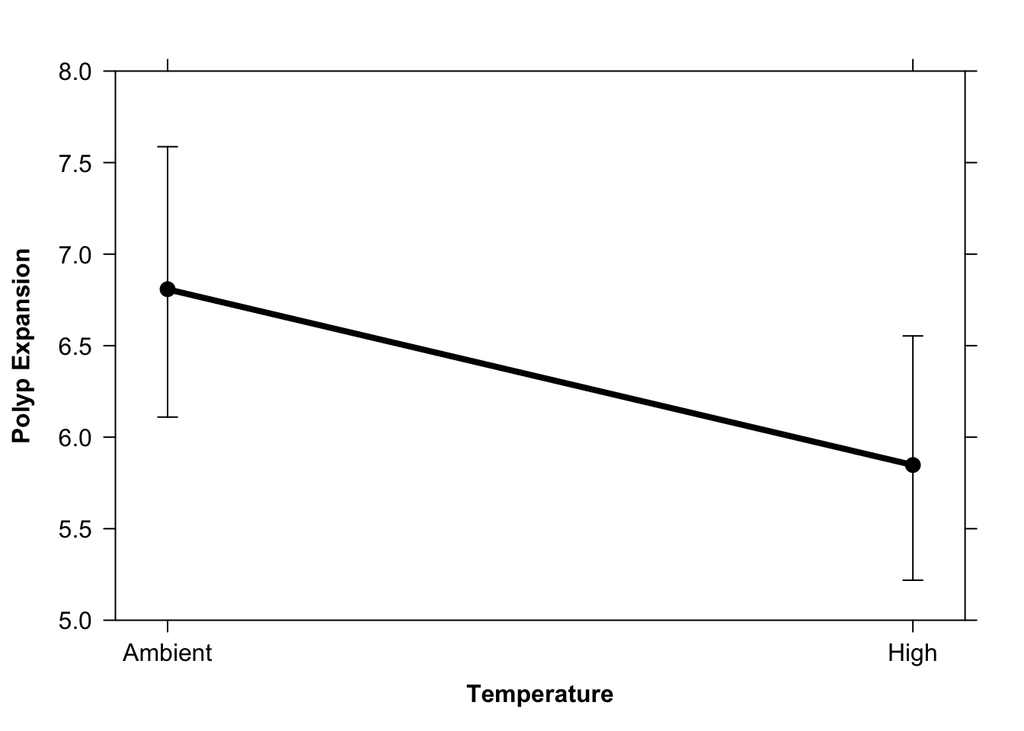

```r
eff.stress.polyps1 <- predictorEffect("Treatment", stresspolypmod2)
polyps.stress.effects1<-plot(eff.stress.polyps1,
                   lines=list(multiline=TRUE,
                              col=c("black"),
                              lty=1),
                   confint=list(style="bars", width=4, col="black"),
                   lwd=4,
                   axes=list(y=list(lim=c(5,8))),
                   type="response",
                   ylab=expression(bold("Polyp Expansion")),
                   legend.position="right",
                   xlab=expression(bold("Temperature")),
                   main=""); polyps.stress.effects1
```

```r
                   #lattice=list(key.args=list(space="right",
                                              #border=FALSE,
                                              #title=expression(bold("Genotypic \nRichness")),
                                              #cex=1,
                                              #cex.title=1)));surv.effects1
```

Combine figures for Stress Period:

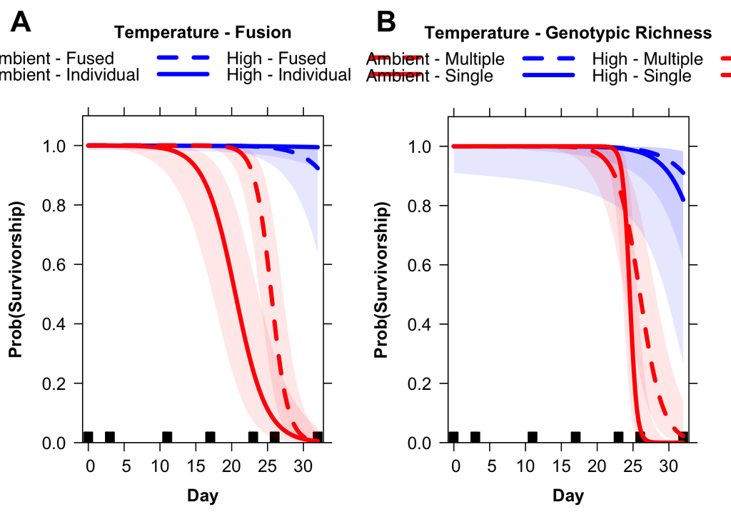

```r
stress_figs<-plot_grid(stress.effectsFUSE, stress.effectsRICHNESS, labels = c("A", "B"), ncol=2, nrow=1, rel_heights= c(1,1), rel_widths = c(1,1), label_size = 20, label_y=1, align="h");stress_figs
```

```r
ggsave(filename="Figures/stress_figs.png", plot=stress_figs, dpi=500, width=20, height=6, units="in")
```

## 7. TEMPERATURE DATA

Load in temperature data from Apex files. Data were recorded every 15 minutes and probes were calibrated to a digital thermometer weekly.

```r
juvtemps<-read.csv("Data/ApexTemps.csv", header=T, na.strings="NA")
#convert Date and Time to date/time format
juvtemps$Date <- as.POSIXct(juvtemps$Date, format="%m/%d/%y %H:%M")

#convert to long format
juvtemps<-juvtemps %>% gather(Tank, Temperature, Tank17:Tank24)
juvtemps$Tank<-as.factor(juvtemps$Tank)

dailymax<-juvtemps[which(juvtemps$TimeDay == "930"),]
dailymax<-juvtemps[which(juvtemps$Phase == "Stress"),]

dailymax$Treatment<-ifelse(dailymax$Tank %in% c("Tank17"), "Ambient",
                            ifelse(dailymax$Tank %in% c("Tank18"), "Ambient",
                            ifelse(dailymax$Tank %in% c("Tank19"), "High",
                            ifelse(dailymax$Tank %in% c("Tank20"), "High",
                            ifelse(dailymax$Tank %in% c("Tank21"), "Ambient",
                            ifelse(dailymax$Tank %in% c("Tank22"), "High",
                            ifelse(dailymax$Tank %in% c("Tank23"), "Ambient",
                            ifelse(dailymax$Tank %in% c("Tank24"), "High",NA))))))))

maxtemps <- ddply(dailymax, c("Treatment"), summarise,
                   N    = length(Temperature[!is.na(Temperature)]),
                   mean = mean(Temperature, na.rm=TRUE),
                   sd   = sd(Temperature, na.rm=TRUE),
                   se   = sd / sqrt(N),
                   max = max(Temperature, na.rm=TRUE),
                   lower = mean-sd,
                   upper = mean+sd
                   )

juvtemps$Period<-ifelse(juvtemps$Phase %in% c("Stress"), "Stress",
                            ifelse(juvtemps$Phase %in% c("Stress2"), "Stress",
                            ifelse(juvtemps$Phase %in% c("Acclimation"), "Stress",
                            ifelse(juvtemps$Phase %in% c("Hurricane"), "Hurricane",
                            ifelse(juvtemps$Phase %in% c("Ambient"), "Grow-Out",NA)))))
```

Plot timeseries of temperature data with tank temperature in colors.

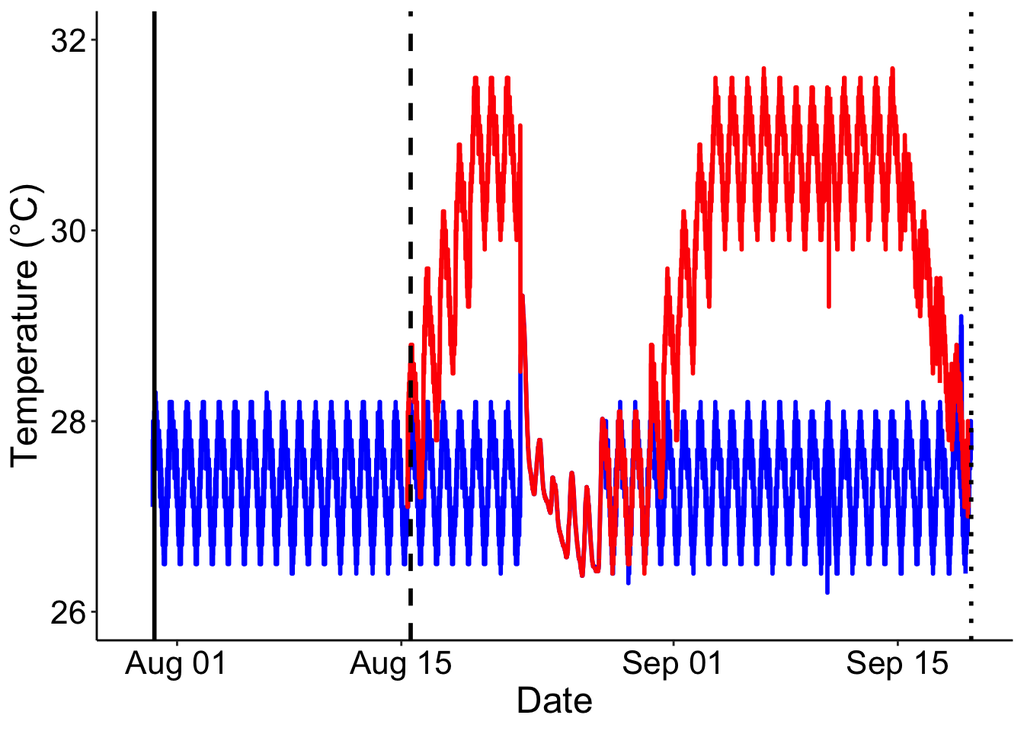

```r
#subset temperature measurements

juvtempsHIGH<-subset(juvtemps, Period==c("Stress"), c(Date, TimeDay, Phase, Tank, Temperature, Period))
juvtempsHIGH$Treatment<-ifelse(juvtempsHIGH$Tank %in% c("Tank17"), "Ambient",
                            ifelse(juvtempsHIGH$Tank %in% c("Tank18"), "Ambient",
                            ifelse(juvtempsHIGH$Tank %in% c("Tank19"), "High",
                            ifelse(juvtempsHIGH$Tank %in% c("Tank20"), "High",
                            ifelse(juvtempsHIGH$Tank %in% c("Tank21"), "Ambient",
                            ifelse(juvtempsHIGH$Tank %in% c("Tank22"), "High",
                            ifelse(juvtempsHIGH$Tank %in% c("Tank23"), "Ambient",
                            ifelse(juvtempsHIGH$Tank %in% c("Tank24"), "High",NA))))))))

juvtempsHURR<-subset(juvtemps, Period==c("Hurricane"), c(Date, TimeDay, Phase, Tank, Temperature, Period))
juvtempsHURR$Treatment<-ifelse(juvtempsHURR$Tank %in% c("Tank17"), "Ambient",
                            ifelse(juvtempsHURR$Tank %in% c("Tank18"), "Ambient",
                            ifelse(juvtempsHURR$Tank %in% c("Tank19"), "High",
                            ifelse(juvtempsHURR$Tank %in% c("Tank20"), "High",
                            ifelse(juvtempsHURR$Tank %in% c("Tank21"), "Ambient",
                            ifelse(juvtempsHURR$Tank %in% c("Tank22"), "High",
                            ifelse(juvtempsHURR$Tank %in% c("Tank23"), "Ambient",
                            ifelse(juvtempsHURR$Tank %in% c("Tank24"), "High",NA))))))))

juvtempsGROW<-subset(juvtemps, Period==c("Grow-Out"), c(Date, TimeDay, Phase, Tank, Temperature, Period))
juvtempsGROW$Treatment<-ifelse(juvtempsGROW$Tank %in% c("Tank17"), "Ambient",
                            ifelse(juvtempsGROW$Tank %in% c("Tank18"), "Ambient",
                            ifelse(juvtempsGROW$Tank %in% c("Tank19"), "Ambient",
                            ifelse(juvtempsGROW$Tank %in% c("Tank20"), "Ambient",
                            ifelse(juvtempsGROW$Tank %in% c("Tank21"), "Ambient",
                            ifelse(juvtempsGROW$Tank %in% c("Tank22"), "Ambient",
                            ifelse(juvtempsGROW$Tank %in% c("Tank23"), "Ambient",
                            ifelse(juvtempsGROW$Tank %in% c("Tank24"), "Ambient",NA))))))))

juvtemps<-rbind(juvtempsHIGH, juvtempsGROW)
juvtemps<-rbind(juvtemps, juvtempsHURR)

TimeSeries1j<-ggplot(juvtemps, aes(x = Date, y = Temperature)) +
  geom_line(aes(color = Treatment), size = 1) +
  scale_color_manual(values=c("blue", "red")) +
  ylab("Temperature (°C)")+
  xlab("Date")+
  ylim(26,32)+
  geom_vline(xintercept = as.POSIXct(as.Date(c("2018-07-31 10:00:00"))), linetype="solid",
                color = "black", size=1)+
  geom_vline(xintercept = as.POSIXct(as.Date(c("2018-08-16 00:00:00"))), linetype="dashed",
                color = "black", size=1)+
  geom_vline(xintercept = as.POSIXct(as.Date(c("2018-09-20 16:00:00"))), linetype="dotted",
                color = "black", size=1)+
  theme_classic()+
  scale_x_datetime(limits = as.POSIXct(as.Date(c("2018-07-30 09:00:00", "2018-09-20 21:00:00")))) +
  theme(legend.position="none")+
  theme(text = element_text(size = 18, color="black"))+
  theme(axis.text = element_text(size=16, color="black"));TimeSeries1j
```

Plot by time of day by summarizing the mean temp at each time of day for each tank. Display the mean temperatures of each treatment during the Stress test phase (excluding the pause in treatment due to the hurricane system shutdown).

```r
#subset juv temps for the stress period
juvtempsSTRESS<-juvtemps
juvtempsSTRESS$Period<-ifelse(juvtempsSTRESS$Phase %in% c("Stress"), "Stress",
                            ifelse(juvtempsSTRESS$Phase %in% c("Stress2"), "Stress",
                            ifelse(juvtempsSTRESS$Phase %in% c("Acclimation"), "Acclimation",
                            ifelse(juvtempsSTRESS$Phase %in% c("Hurricane"), "Hurricane",
                            ifelse(juvtempsSTRESS$Phase %in% c("Ambient"), "Grow-Out",NA)))))

juvtempsSTRESS

juvtempsSTRESS<-juvtempsSTRESS[which(juvtempsSTRESS$Phase == "Stress"),]


QuarterlyJ <- ddply(juvtempsSTRESS, c("TimeDay", "Treatment"), summarise,
                   N    = length(Temperature[!is.na(Temperature)]),
                   mean = mean(Temperature, na.rm=TRUE),
                   sd   = sd(Temperature, na.rm=TRUE),
                   se   = sd / sqrt(N),
                   max = max(Temperature, na.rm=TRUE),
                   lower = mean-sd,
                   upper = mean+sd
                   )

MeansJtemp <- ddply(juvtemps, c("Period", "Treatment"), summarise,
                   N    = length(Temperature[!is.na(Temperature)]),
                   mean = mean(Temperature, na.rm=TRUE),
                   sd   = sd(Temperature, na.rm=TRUE),
                   se   = sd / sqrt(N)
                   )
MeansJtemp

MeansJtemp2 <- ddply(juvtemps, c("Treatment"), summarise,
                   N    = length(Temperature[!is.na(Temperature)]),
                   mean = mean(Temperature, na.rm=TRUE),
                   max = max(Temperature, na.rm=TRUE),
                   sd   = sd(Temperature, na.rm=TRUE),
                   se   = sd / sqrt(N)
                   )
MeansJtemp2
```

[output not shown]

Generate final figure.

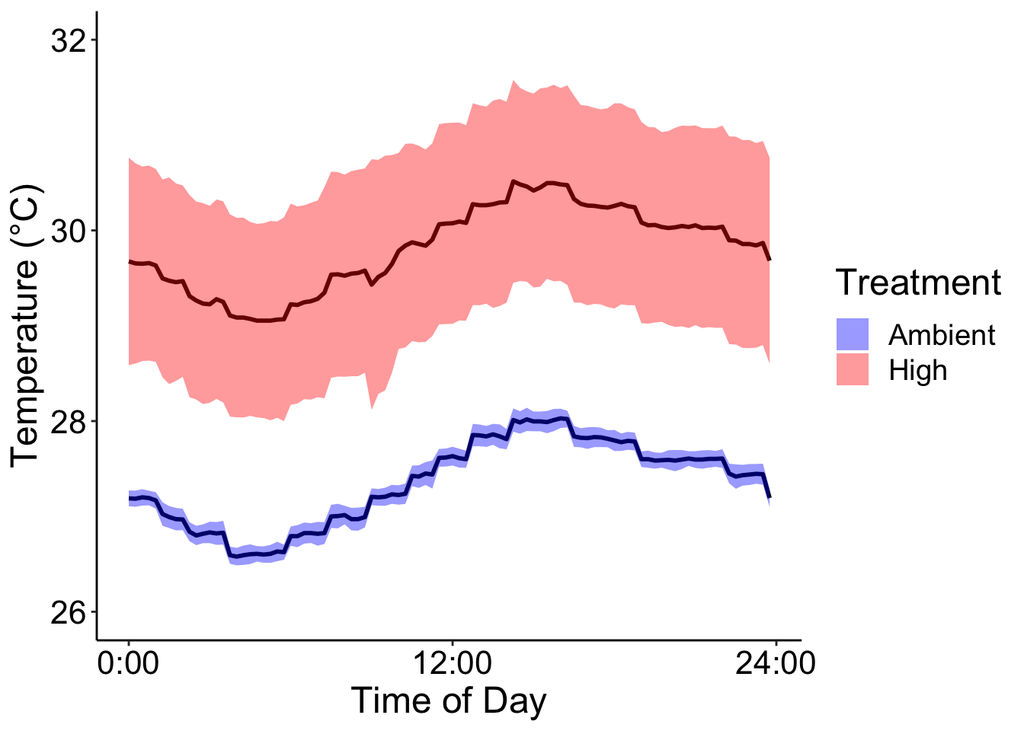

```r
JuvTempsDay<-ggplot(QuarterlyJ, aes(x = TimeDay, y = mean, color=Treatment, fill=Treatment)) +
  geom_line(color="black", size = 1) +
  #facet_wrap(~Period) +
  scale_x_continuous(breaks=c(0, 720, 1440), labels=c("0:00", "12:00", "24:00")) +
  scale_color_manual(values = c("blue", "red")) +
  scale_fill_manual(values = c("blue", "red")) +
  theme_classic() +
  geom_ribbon(aes(ymin=QuarterlyJ$lower, ymax=QuarterlyJ$upper), linetype=2, alpha=0.4, color=NA) +
  ylab("Temperature (°C)") +
  xlab("Time of Day") +
  ylim(26,32)+
  theme(text = element_text(size = 18, color="black"))+
  theme(panel.margin = unit(2, "lines"))+
  theme(axis.text = element_text(size=16, color="black")); JuvTempsDay
```

Combine figures for temperature.

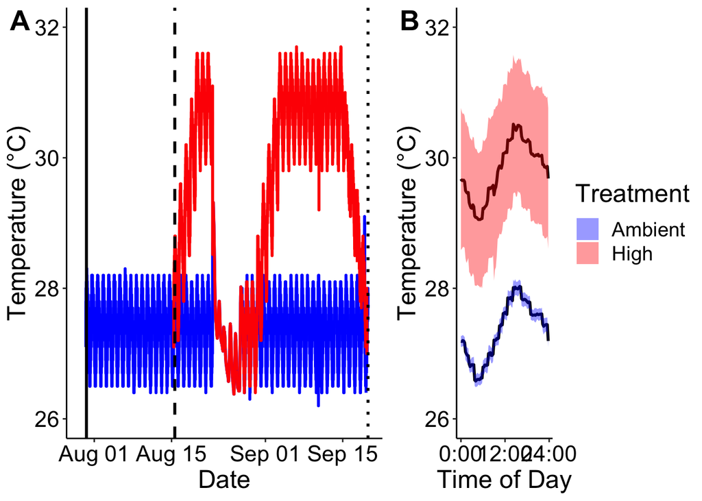

```r
temp_figs<-plot_grid(TimeSeries1j, JuvTempsDay, labels = c("A", "B"), ncol=2, nrow=1, rel_heights= c(1,1), rel_widths = c(1,0.8), label_size = 20, label_y=1, align="h");temp_figs
```

```r
ggsave(filename="Figures/temp_figs.png", plot=temp_figs, dpi=500, width=14, height=6, units="in")
```